# Train PLS Diabetes

Avan Suinesiaputra

2023-06-27

```r
knitr::opts_chunk$set(echo = TRUE)

library(caret)
library(R.matlab)
library(tidyverse)
library(pROC)
library(broom)
library(kableExtra)
library(rlang)
library(testthat)
library(doParallel)

source("train_pls_formulae.R")
```

```r
n_cores <- detectCores()
message(sprintf("Using %d cores", n_cores))
```

```
## Using 20 cores
```

*Note: the output HTML & the training RDS data are saved in PLS.*

Parameters

| name | value |
| --- | --- |
| Cohort name | UKBB |
| Risk factor | Diabetes |
| Maximum number of PLS components | 30 |
| Pct PCA variance explained (%) | 99.9 |
| Data file | MESA_UKBB_FinalData.csv |

## Get the data

1. Read the variable and select only cases within the cohort UKBB
2. Select ID, Age, Gender & the risk factor Diabetes.
3. Recode the risk factor values where TRUE -> RISK and FALSE -> NO_RISK

```r
dt.ori <- read_csv(datafile, show_col_types = FALSE) %>%
  filter(Cohort == params$cohort) %>%
  select(c(ID, Age, Sex, NoRisk, sym(params$rf_name))) %>%
  mutate(
    !!sym(params$rf_name) := recode_factor(as.factor(!!sym(params$rf_name)), "FALSE" = "NO_RISK", "TRUE" = "RISK"),
    Sex = as.factor(Sex)
  )

message(sprintf("Original %s: %d rows", params$cohort, nrow(dt.ori)))
```

```
## Original UKBB: 2960 rows
```

4. Define the NO RISK sub-cohort, which is all cases without any risk factor at all

```r
dt.norf <- filter(dt.ori, NoRisk)

message(sprintf("No risk sub-cohort %s: %d rows", params$cohort, nrow(dt.norf)))
```

```
## No risk sub-cohort UKBB: 645 rows
```

5. Filter cases having Diabetes

```r
dt.rf <- filter(dt.ori,  !!sym(params$rf_name) == "RISK")

message(sprintf("Risk sub-cohort %s: %d rows", params$cohort, nrow(dt.rf)))
```

```
## Risk sub-cohort UKBB: 159 rows
```

*Sanity check: the intersection between NO_RISK and RISK id’s should be zero*

```r
test_that("Unique IDs", {
  expect_equal(length(intersect(dt.rf$ID, dt.norf$ID)), 0)
})
```

```
## Test passed 🎊
```

6. Final data

```r
dt <- bind_rows(dt.norf, dt.rf) %>%
  select(-c(NoRisk))

message(sprintf("Training data: %d rows", nrow(dt)))
```

```
## Training data: 804 rows
```

```r
dt %>% select(c(Sex, sym(params$rf_name))) %>% table() %>%
  kbl(caption = "Risk factor distributions") %>% kable_styling("hover", full_width = F, position="left")
```

Risk factor distributions

|  | NO_RISK | RISK |
| --- | --- | --- |
| female | 395 | 65 |
| male | 250 | 94 |

*just for fixing plot title*

```r
cohort_title <- if_else(params$cohort == "UKBB", "UK Biobank", params$cohort)
```

## Prepare the PC scores

1. Determine how many PCA components to use

```r
model <- list()

expl_vars <- readMat(paste("PCA", params$cohort, "PCA_explained.mat", sep = "/"))$explained
model$npcs <- length(expl_vars[cumsum(expl_vars) < params$pca_var])
message(sprintf("Number of PC components with %.2f%% variance explained: %d", params$pca_var, model$npcs))
```

```
## Number of PC components with 99.90% variance explained: 210
```

```r
rm(expl_vars)
```

2. Read PCA components
3. Combine with Age, Sex & the risk factor using the same ID

```r
# this is a combined X (Age + Sex + PCScores) & Y (Risk Factor)
model$dt.train <- inner_join(
  dt %>%
    select(c(ID, Age, Sex, sym(params$rf_name))) %>%
    mutate(
      Sex = as.numeric(Sex)
    ),
  cbind(
    read.csv(paste("PCA", sprintf("%s_ids.csv", params$cohort), sep="/")),
    readMat(paste("PCA", params$cohort, "PCA_score.mat", sep="/"))$score[, 1:model$npcs]
  ),
  by = c("ID" = "ID"))

# check the cohort
message(sprintf("Number of cases = %d, columns = %d", nrow(model$dt.train), ncol(model$dt.train)))
```

```
## Number of cases = 804, columns = 214
```

4. Sanity checks.

This should only include that specific cohort

```r
test_that("Check cohort", {
  expect_equal(substr(params$cohort, 1, 3), (model$dt.train %>% transmute(cohort = substr(ID, 1, 3)) %>% distinct())$cohort)
})
```

```
## Test passed 🎊
```

No NA rows

```r
test_that("No NA rows", {
  expect_equal(0, sum(is.na(model$dt.train)))
})
```

```
## Test passed 🥇
```

## Find optimal number of PLS components

```r
(m_kcv <- train_pls(as.formula(sprintf("%s ~ Age + Sex + .", params$rf_name)), dt = model$dt.train %>% select(-c(ID)), n_comps=params$max_ncomps))
```

[output not shown]

[output cut: 30 more lines]

Get the number of component

```r
(model$ncomp <- m_kcv$bestTune$ncomp)
```

```
## [1] 16
```

Plot for analysis

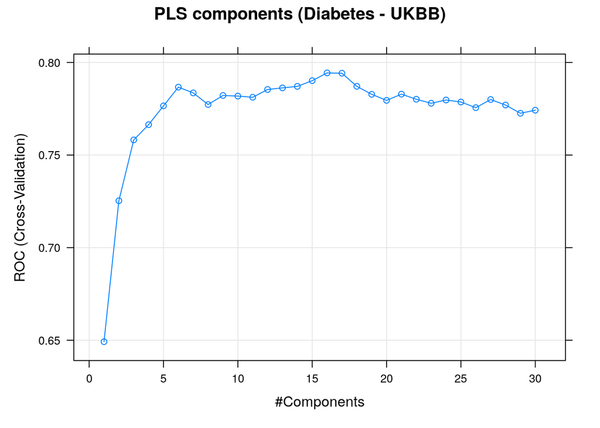

```r
plot(m_kcv, main=sprintf("PLS components (%s - %s)", params$rf_name, params$cohort))
```

## Train PLS

After we get the optimal parameter, we train the PLS using leave-one-out cross validation. Since this will take time, we need multiple cores to compute.

Create train control with LOOCV

```r
tc_loo <- trainControl(method="LOOCV", savePredictions = "all", classProbs = TRUE, verboseIter=FALSE,
                       summaryFunction = twoClassSummary, allowParallel = TRUE)
```

```r
# parallel cores
if( n_cores > 1 ) {
  cl <- makeCluster(n_cores - 1, outfile = "")
  registerDoParallel(cl)
  getDoParWorkers()
}
```

```
## [1] 19
```

```r
# train (take a while)
model$pls <- train(
  form = sprintf("%s ~ Age + Sex + .", params$rf_name) %>% as.formula(),
  data = model$dt.train %>% select(-ID),
  method = "pls",
  metric = "ROC",
  preProc = c("center"),
  tuneGrid = data.frame(ncomp=model$ncomp),
  probMethod = "softmax",
  trControl = tc_loo
)

# unregister cores
if( n_cores > 1 ) {
  stopCluster(cl)
  registerDoSEQ()
}
```

```r
model$pls
```

```
## Partial Least Squares
##
## 804 samples
## 212 predictors
##   2 classes: 'NO_RISK', 'RISK'
##
## Pre-processing: centered (212)
## Resampling: Leave-One-Out Cross-Validation
## Summary of sample sizes: 803, 803, 803, 803, 803, 803, ...
## Resampling results:
##
##   ROC        Sens       Spec
##   0.7908927  0.9333333  0.3584906
##
## Tuning parameter 'ncomp' was held constant at a value of 16
```

Or use getTrainPerf to get the results

```r
getTrainPerf(model$pls)
```

```
##    TrainROC TrainSens TrainSpec method
## 1 0.7908927 0.9333333 0.3584906    pls
```

The prediction is in `model$pls$pred` data frame. Let’s plot the training ROC

Check the level order, because RISK should be the first, since that’s the prediction target.

```r
levels(model$pls$pred$obs)
```

```
## [1] "NO_RISK" "RISK"
```

Calculate the ROC. *Note we need to reverse the category level*.

```r
(m_roc <- roc(model$pls$pred$obs, model$pls$pred$RISK, levels = rev(levels(model$pls$pred$obs))))
```

```
##
## Call:
## roc.default(response = model$pls$pred$obs, predictor = model$pls$pred$RISK,     levels = rev(levels(model$pls$pred$obs)))
##
## Data: model$pls$pred$RISK in 159 controls (model$pls$pred$obs RISK) > 645 cases (model$pls$pred$obs NO_RISK).
## Area under the curve: 0.7909
```

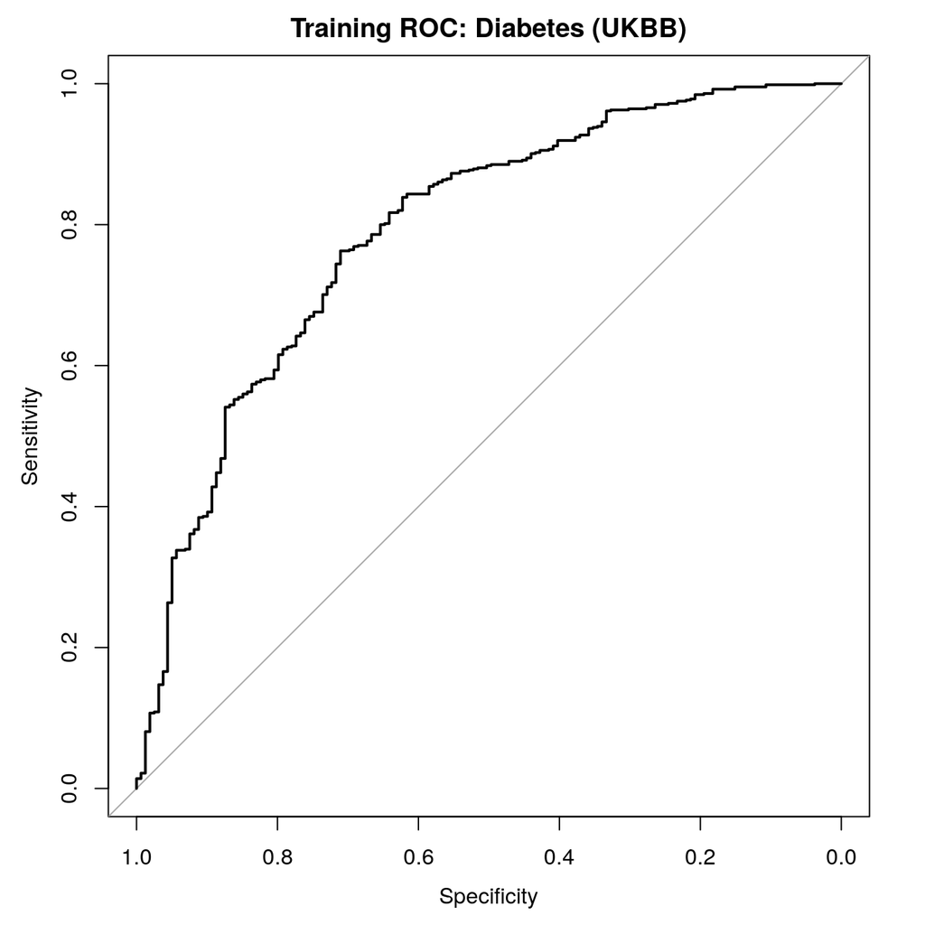

```r
plot(m_roc, legacy_axes=TRUE, main = sprintf("Training ROC: %s (%s)", params$rf_name, params$cohort))
```

### Show the first 10 coefficients

```r
coef(model$pls$finalModel)[1:10,,]
```

```
##           NO_RISK          RISK
## Age -6.324943e-03  6.324943e-03
## Sex  3.964181e-04 -3.964181e-04
## `1`  3.696745e-04 -3.696745e-04
## `2`  2.286540e-04 -2.286540e-04
## `3` -4.476987e-04  4.476987e-04
## `4` -9.143891e-04  9.143891e-04
## `5`  4.922849e-04 -4.922849e-04
## `6`  7.756114e-04 -7.756114e-04
## `7` -9.794765e-05  9.794765e-05
## `8`  8.053501e-04 -8.053501e-04
```

## Save the results

Add some other information too in the model

```r
model$cohort <- params$cohort
model$risk_factor <- params$rf_name
model$pca_var <- params$pca_var
```

```r
model_filename <- paste(params$output_folder, sprintf("PLS_%s_%s.rds", params$cohort, params$rf_name), sep="/")
write_rds(model, file=model_filename, compress = "gz")
message(sprintf("Saved model to %s", model_filename))
```

```
## Saved model to PLS/PLS_UKBB_Diabetes.rds
```